# DataVis_part2_2017-05-01.Rmd

##### 2. What does labs() do?

Modifies axis, legend, and plot labels.

```r
example(labs)
```

```
##
## labs> p <- ggplot(mtcars, aes(mpg, wt, colour = cyl)) + geom_point()
##
## labs> p + labs(colour = "Cylinders")
```

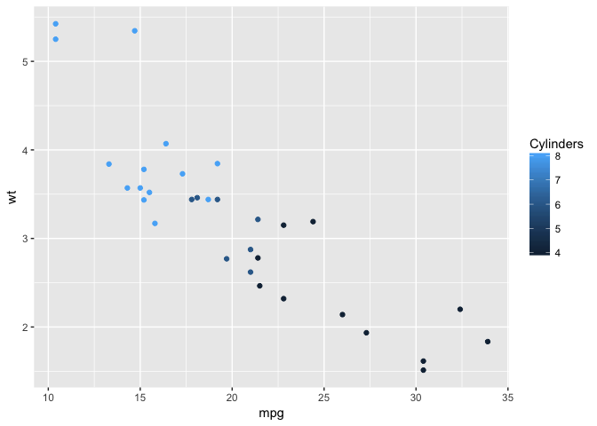

```
##
## labs> p + labs(x = "New x label")
```

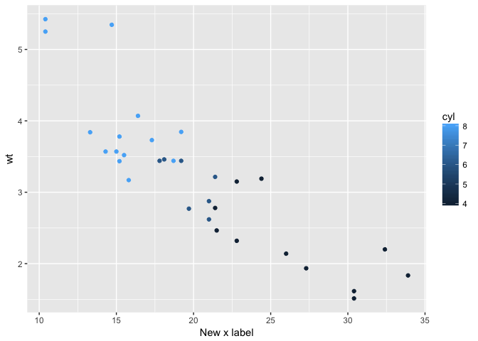

```
##
## labs> # The plot title appears at the top-left, with the subtitle
## labs> # display in smaller text underneath it
## labs> p + labs(title = "New plot title")
```

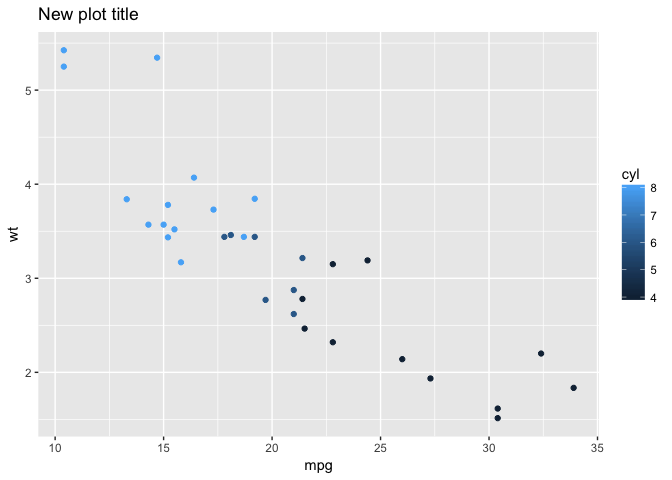

```
##
## labs> p + labs(title = "New plot title", subtitle = "A subtitle")
```

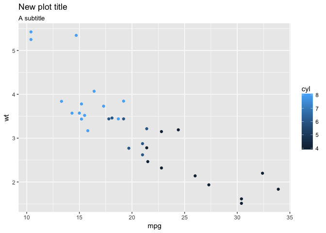

```
##
## labs> # The caption appears in the bottom-right, and is often used for
## labs> # sources, notes or copyright
## labs> p + labs(caption = "(based on data from ...)")
```

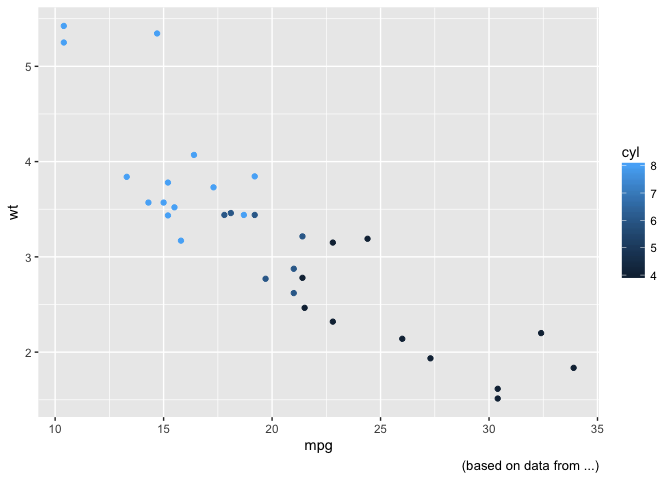

##### 3. coord_quickmap vs coord_map

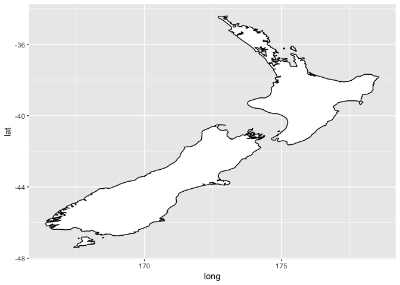

```r
nz <- map_data("nz")
ggplot(nz, aes(long, lat, group = group)) +
  geom_polygon(fill = "white", colour = "black")
```

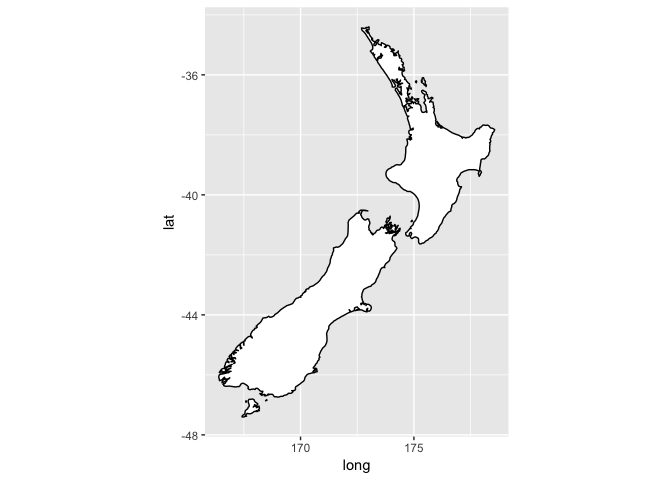

```r
#weird proportions

ggplot(nz, aes(long, lat, group = group)) +
  geom_polygon(fill = "white", colour = "black") +
  coord_quickmap()
```

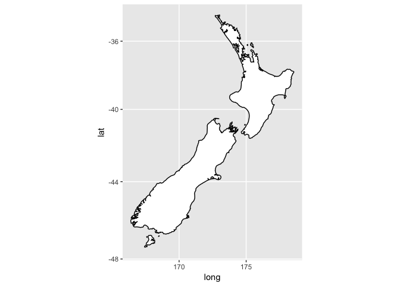

```r
ggplot(nz, aes(long, lat, group = group)) +
  geom_polygon(fill = "white", colour = "black") +
  coord_map()
```

```r
# proportions slightly different
?coord_map  # more precise than quickmap.
# quickmap is faster - best close to equator
```

##### 4. relationship between cty and hwy mpg?

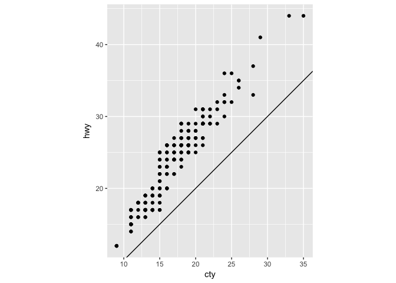

```r
ggplot(data = mpg, mapping = aes(x = cty, y = hwy)) +
  geom_point() +
  geom_abline() +
  coord_fixed()
```

roughly linear relationship between hwy and city mileage

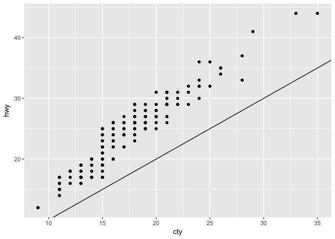

```r
ggplot(data = mpg, mapping = aes(x = cty, y = hwy)) +
  geom_point() +
  geom_abline()
```

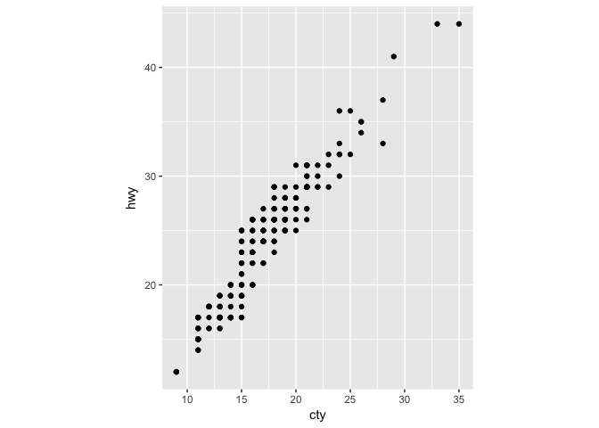

```r
# without coord_fixed, graph not necesarily square.

ggplot(data = mpg, mapping = aes(x = cty, y = hwy)) +
  geom_point() +
  coord_fixed()
```

```r
# abline adds a diagonal line
```

### Section 3.10: Grammar of graphics

7 parameters: data, the geom function, aes mappings, the stat, position adjustment, coordinate function, and faceting.

## Workflow: basics

### Section 4.1: Coding basics

```r
#  <-  nice shortcut!  Alt and minus key
```

#### 4.4 Exercises

##### 1. spot the error

Annoying - a 1 not an i in the name

##### 2. fix the errors

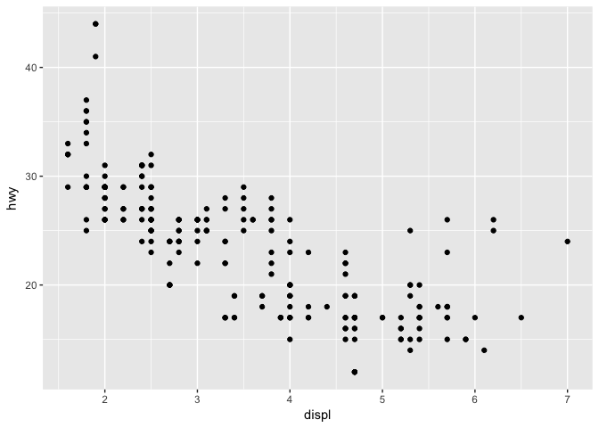

```r
library(tidyverse)

ggplot(data = mpg) +  # data, not dota
  geom_point(mapping = aes(x = displ, y = hwy))
```

```r
filter(mpg, cyl == 8) # filter, not fliter; and must be == 8
```

```
## # A tibble: 70 × 11
##    manufacturer              model displ  year   cyl      trans   drv
##           <chr>              <chr> <dbl> <int> <int>      <chr> <chr>
## 1          audi         a6 quattro   4.2  2008     8   auto(s6)     4
## 2     chevrolet c1500 suburban 2wd   5.3  2008     8   auto(l4)     r
## 3     chevrolet c1500 suburban 2wd   5.3  2008     8   auto(l4)     r
## 4     chevrolet c1500 suburban 2wd   5.3  2008     8   auto(l4)     r
## 5     chevrolet c1500 suburban 2wd   5.7  1999     8   auto(l4)     r
## 6     chevrolet c1500 suburban 2wd   6.0  2008     8   auto(l4)     r
## 7     chevrolet           corvette   5.7  1999     8 manual(m6)     r
## 8     chevrolet           corvette   5.7  1999     8   auto(l4)     r
## 9     chevrolet           corvette   6.2  2008     8 manual(m6)     r
## 10    chevrolet           corvette   6.2  2008     8   auto(s6)     r
## # ... with 60 more rows, and 4 more variables: cty <int>, hwy <int>,
## #   fl <chr>, class <chr>
```

```r
filter(diamonds, carat > 3) # diamonds, not diamond
```

```
## # A tibble: 32 × 10
##    carat     cut color clarity depth table price     x     y     z
##    <dbl>   <ord> <ord>   <ord> <dbl> <dbl> <int> <dbl> <dbl> <dbl>
## 1   3.01 Premium     I      I1  62.7    58  8040  9.10  8.97  5.67
## 2   3.11    Fair     J      I1  65.9    57  9823  9.15  9.02  5.98
## 3   3.01 Premium     F      I1  62.2    56  9925  9.24  9.13  5.73
## 4   3.05 Premium     E      I1  60.9    58 10453  9.26  9.25  5.66
## 5   3.02    Fair     I      I1  65.2    56 10577  9.11  9.02  5.91
## 6   3.01    Fair     H      I1  56.1    62 10761  9.54  9.38  5.31
## 7   3.65    Fair     H      I1  67.1    53 11668  9.53  9.48  6.38
## 8   3.24 Premium     H      I1  62.1    58 12300  9.44  9.40  5.85
## 9   3.22   Ideal     I      I1  62.6    55 12545  9.49  9.42  5.92
## 10  3.50   Ideal     H      I1  62.8    57 12587  9.65  9.59  6.03
## # ... with 22 more rows
```

##### 3. keyboard shorcut

Can access it via Alt + Shift + K Can also go to file:///Applications/RStudio.app/Contents/Resources/www/docs/keyboard.htm Or, look under the ‘Tools’ menu